# Product_Segmentation

## Product Segmentation Case Study

## Problem Statement

### Context

When you think of sneakers for a trip, the importance of good footwear cannot be discarded, and the obvious brands that come to mind are Adidas and Nike. Adidas vs Nike is a constant debate as the two giants in the apparel market, with a large market cap and market share, battle it out to come on top. As a newly hired Data Scientist in a market research company, you have been given the task of extracting insights from the data of men's and women's shoes, and grouping products together to identify similarities and differences between the product range of these renowned brands.

### Objective

To perform an exploratory data analysis and cluster the products based on various factors using k-means algorithm and agglomerative clustering

### Key Questions

- Which variables are most important for clustering?
- How each cluster is different from the others?
- What are the business recommendations?

### Data Description

The dataset consists of 3268 products from Nike and Adidas with features of information including their ratings, discount, sales price, listed price, product name, and the number of reviews.

- Product Name: Name of the product
- Product ID: ID of the product
- Listing Price: Listed price of the product
- Sale Price: Sale price of the product
- Discount: Percentage of discount on the product
- Brand: Brand of the product
- Rating: Rating of the product
- Reviews: Number of reviews for the product

## Importing Libraries

```python
# Suppressing warnings
import warnings
warnings.filterwarnings('ignore')

# Data management libraries
import numpy as np
import pandas as pd

# Visualization libraries
import matplotlib.pyplot as plt
import seaborn as sns
%matplotlib inline

# Clustering libraries
from sklearn.cluster import KMeans, AgglomerativeClustering
from scipy.cluster.hierarchy import linkage, cophenet, dendrogram
from yellowbrick.cluster import SilhouetteVisualizer, KElbowVisualizer
from scipy.spatial.distance import cdist, pdist
from sklearn.metrics import silhouette_score

# Scaling and preprocessing libraries
from scipy.stats import zscore
from sklearn.preprocessing import StandardScaler, MinMaxScaler

# Setting the theme and fontsize of figures
sns.set_theme(style = 'darkgrid', font_scale = 1.13)

# Restricting the float value of a dataframe to 3 decimal points
pd.set_option('display.float_format', lambda x: '%.3f' % x)
# Removing the limit for the number of displayed columns in a dataframe
pd.set_option("display.max_columns", None)

# Mounting the drive
from google.colab import drive
drive.mount('/content/drive/')
```

## Loading the Dataset

```python
# Importing the dataset
data_orig = pd.read_csv('/content/drive/MyDrive/Python_files/data_add_nik.csv')
# Ensuring the original data remains unchanged
df = data_orig.copy()
```

## Overview of the Dataset

- Sanity checks
- General information on data columns

### Viewing the Top and Bottom of the Dataset

```python
# First five rows
df.head()
```

|  | Product Name | Product ID | Listing Price | Sale Price | Discount | Brand | Rating | Reviews |
| --- | --- | --- | --- | --- | --- | --- | --- | --- |
| 0 | Women's adidas Originals NMD_Racer Primeknit S... | AH2430 | 14999 | 7499 | 50 | Adidas Adidas ORIGINALS | 4.800 | 41 |
| 1 | Women's adidas Originals Sleek Shoes | G27341 | 7599 | 3799 | 50 | Adidas ORIGINALS | 3.300 | 24 |
| 2 | Women's adidas Swim Puka Slippers | CM0081 | 999 | 599 | 40 | Adidas CORE / NEO | 2.600 | 37 |
| 3 | Women's adidas Sport Inspired Questar Ride Shoes | B44832 | 6999 | 3499 | 50 | Adidas CORE / NEO | 4.100 | 35 |
| 4 | Women's adidas Originals Taekwondo Shoes | D98205 | 7999 | 3999 | 50 | Adidas ORIGINALS | 3.500 | 72 |

```python
# Last five rows
df.tail()
```

|  | Product Name | Product ID | Listing Price | Sale Price | Discount | Brand | Rating | Reviews |
| --- | --- | --- | --- | --- | --- | --- | --- | --- |
| 3263 | Air Jordan 8 Retro | CI1236-100 | 15995 | 12797 | 0 | Nike | 5.000 | 1 |
| 3264 | Nike Phantom Venom Club IC | AO0578-717 | 4995 | 3497 | 0 | Nike | 0.000 | 0 |
| 3265 | Nike Mercurial Superfly 7 Academy TF | AT7978-414 | 8495 | 5947 | 0 | Nike | 5.000 | 1 |
| 3266 | Nike Air Max 98 | AH6799-300 | 0 | 16995 | 0 | Nike | 4.000 | 4 |
| 3267 | Nike P-6000 SE | CJ9585-600 | 8995 | 6297 | 0 | Nike | 0.000 | 0 |

### Shape of the Dataset

```python
print('The dataset has {} features and {} records.'.format(df.shape[1], df.shape[0]))
```

```
The dataset has 8 features and 3268 records.
```

### Viewing the Data Type of Features

```python
df.info()
```

```
<class 'pandas.core.frame.DataFrame'>
RangeIndex: 3268 entries, 0 to 3267
Data columns (total 8 columns):
 #   Column         Non-Null Count  Dtype
---  ------         --------------  -----
 0   Product Name   3268 non-null   object
 1   Product ID     3268 non-null   object
 2   Listing Price  3268 non-null   int64
 3   Sale Price     3268 non-null   int64
 4   Discount       3268 non-null   int64
 5   Brand          3268 non-null   object
 6   Rating         3268 non-null   float64
 7   Reviews        3268 non-null   int64
dtypes: float64(1), int64(4), object(3)
memory usage: 204.4+ KB
```

### Checking for Missing Values and Duplicates

**`Duplicates`**

```python
print('The dataset has {} duplicated records.'.format(df.duplicated().sum()))
```

```
The dataset has 88 duplicated records.
```

```python
# Dropping the duplicated records
df.drop_duplicates(inplace = True)
df = df.reset_index(drop = True)
print('Number of duplicates after dropping the has duplicated records:', df.duplicated().sum())
```

```
Number of duplicates after dropping the has duplicated records: 0
```

```python
# The shape of dataset after removal of duplicates
print('After removal of duplicates, the dataset has {} records.'.format(df.shape[0]))
```

```
After removal of duplicates, the dataset has 3180 records.
```

**`Missing Values`**

```python
print('The dataset has {} missing entries.'.format(df.isnull().sum().sum()))
```

```
The dataset has 0 missing entries.
```

### Dropping Unhelpful Features

Product Name and ID are too unique and not very informative. So we choose to drop both.

```python
df.drop(columns = ['Product Name', 'Product ID'], axis = 1, inplace = True)
df.head()
```

|  | Listing Price | Sale Price | Discount | Brand | Rating | Reviews |
| --- | --- | --- | --- | --- | --- | --- |
| 0 | 14999 | 7499 | 50 | Adidas Adidas ORIGINALS | 4.800 | 41 |
| 1 | 7599 | 3799 | 50 | Adidas ORIGINALS | 3.300 | 24 |
| 2 | 999 | 599 | 40 | Adidas CORE / NEO | 2.600 | 37 |
| 3 | 6999 | 3499 | 50 | Adidas CORE / NEO | 4.100 | 35 |
| 4 | 7999 | 3999 | 50 | Adidas ORIGINALS | 3.500 | 72 |

### Statistical Summary

**`Numerical Variables`**

```python
df.describe(include = np.number).T
```

|  | count | mean | std | min | 25% | 50% | 75% | max |
| --- | --- | --- | --- | --- | --- | --- | --- | --- |
| Listing Price | 3180.000 | 6992.708 | 4677.133 | 0.000 | 4599.000 | 5999.000 | 8999.000 | 29999.000 |
| Sale Price | 3180.000 | 6027.743 | 4192.481 | 449.000 | 2999.000 | 4599.000 | 7995.000 | 36500.000 |
| Discount | 3180.000 | 27.619 | 22.492 | 0.000 | 0.000 | 40.000 | 50.000 | 60.000 |
| Rating | 3180.000 | 3.267 | 1.394 | 0.000 | 2.600 | 3.500 | 4.400 | 5.000 |
| Reviews | 3180.000 | 41.530 | 31.374 | 0.000 | 12.000 | 39.000 | 69.000 | 223.000 |

**`Categorical Variables`**

```python
cat_sum = df.describe(include = ['object']).T
cat_sum['frac'] = cat_sum['freq']/cat_sum['count']
cat_sum
```

|  | count | unique | top | freq | frac |
| --- | --- | --- | --- | --- | --- |
| Brand | 3180 | 5 | Adidas CORE / NEO | 1111 | 0.349 |

### Treating the Missing Values

We'll proceed to fill in the missing values in the listing price column (zero values) using the available sale price and discount. In fact:

Listing Price = Sale Price * 1/(1 - Discount/100)

```python
for i in range(df.shape[0]):
    if df.loc[i, 'Listing Price'] > 0:
        continue
    df.loc[i, 'Listing Price'] = df.loc[i, 'Sale Price']*(1/(1-0.01*df.loc[i, 'Discount']))
```

```python
# Checking the number of missing values (records with zero listing price) after imputation
print('The dataset has {} data points with zero as listing price.'.format(df.loc[df['Listing Price'] == 0].shape[0]))
```

```
The dataset has 0 data points with zero as listing price.
```

```python
# Checking the statistical properties of the listing price after imputation
df.describe(include = np.number)['Listing Price']
```

```
count    3180.000
mean     8268.209
std      4363.365
min       899.000
25%      4999.000
50%      7599.000
75%     10995.000
max     36500.000
Name: Listing Price, dtype: float64
```

#### Observations:

After imputation, the mean and median of listing price have increased by 18% and 26.7%, respectively.

### Shortening the Brand Names

Here, we shorten the name of some of brands, and merge the "Adidas Adidas ORIGINALS" brand with "Adidas ORIGINALS". Note that there is only one data point for the former.

```python
# The name of brands and their counts
df.Brand.value_counts()
```

```
Adidas CORE / NEO           1111
Adidas ORIGINALS             907
Adidas SPORT PERFORMANCE     606
Nike                         555
Adidas Adidas ORIGINALS        1
Name: Brand, dtype: int64
```

```python
# Shortening the brand names
df.Brand.replace('Adidas CORE / NEO', 'Adidas CORE/NEO', inplace = True)
df.Brand.replace('Adidas Adidas ORIGINALS', 'Adidas ORIGINALS', inplace = True)
df.Brand.replace('Adidas SPORT PERFORMANCE', 'Adidas SPORT', inplace = True)
```

## Exploratory Data Analysis

```python
# Auxiliary function for annotating the bars in a countplot
def countplot_labeling(cntplt, data, perc = True, decimal = 1):
  ''' This function gets a countplot and the dataset that has generated
  the plot to produce the values corresponding to each bar (category).
  If perc = True, percentages will be shown.'''

  from math import isnan

  total = data.shape[0]  # total number of values in the dataset
  for p in cntplt.patches:
        height_val = float(p.get_height())
        if(isnan(height_val)):
          height_val = 0
        if(abs(height_val - round(height_val)) < 1e-6):
          height_val = int(height_val)
        if perc == True:
          # percentage of each category
          label = "{:.1f}%".format(100*height_val/total)
        else:
          label = "{}".format(round(height_val,decimal))  # count of each category
        x = p.get_x() + p.get_width()/2  # width of the plot
        y = p.get_height()  # height of the plot

        if(height_val == 0):
          label = '0'

        # annotate the bar
        cntplt.annotate(label, (x, y), ha = "center", va = "center", size = 12, xytext = (0, 5), textcoords = "offset points")
```

### Univariate Analysis

**`Brand`**

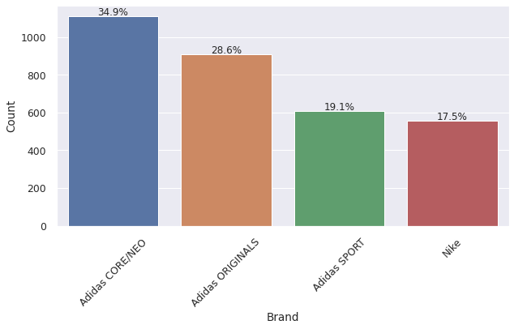

```python
plt.figure(figsize = (10, 5));
cntplt = sns.countplot(data = df, x = 'Brand', order = df.Brand.value_counts().index);
countplot_labeling(cntplt, df);
plt.xticks(rotation = 45);
plt.ylabel('Brand Name');
plt.ylabel('Count');
```

#### Observations:

82.5% of the products are a type of Adidas (with CORE/NEO being the most frequent one), while the remainder are Nike.

**`Listing Price`**

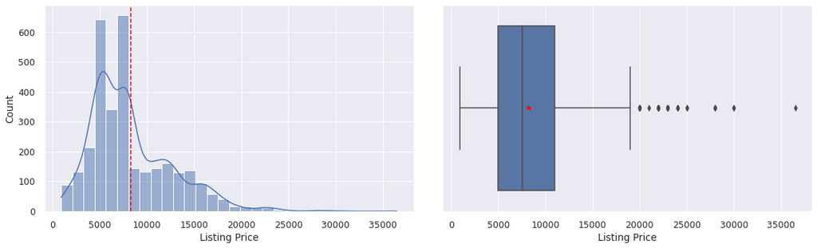

```python
plt.figure(figsize = (16, 5));
plt.subplot(121);
sns.histplot(data = df, x = 'Listing Price', kde = True, bins = 30);
plt.axvline(df['Listing Price'].mean(), color = 'red', linestyle = '--');
plt.subplot(122);
sns.boxplot(data = df, x = 'Listing Price', showmeans = True, meanprops =
                {'marker': '*', 'markerfacecolor': 'red', 'markeredgecolor': 'red', 'markersize': '9'});
plt.tight_layout(w_pad = 3);
```

#### Observations:

The new average of listing price is about 8000, and it has a very right-skewed distribution with several outliers on the right side of the boxplot.

**`Sale Price`**

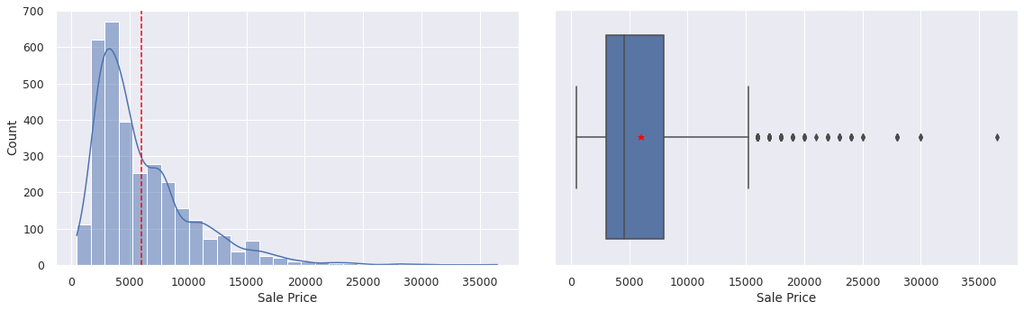

```python
plt.figure(figsize = (16, 5));
plt.subplot(121);
sns.histplot(data = df, x = 'Sale Price', kde = True, bins = 30);
plt.axvline(df['Sale Price'].mean(), color = 'red', linestyle = '--');
plt.subplot(122);
sns.boxplot(data = df, x = 'Sale Price', showmeans = True, meanprops =
                {'marker': '*', 'markerfacecolor': 'red', 'markeredgecolor': 'red', 'markersize': '9'});
plt.tight_layout(w_pad = 3);
```

#### Observations:

Following the distribution of listing price, the sale price also has a highly right-skewed distribution, with its mean being 27% less than that of listing price, which is also nearly equal to the average discount. Mathematically, it didn't have to be, but the proximity is interesting.

**`Discount`**

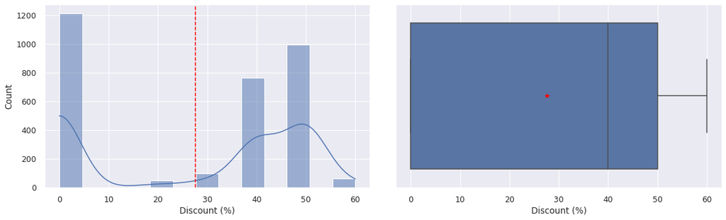

```python
plt.figure(figsize = (16, 5));
plt.subplot(121);
sns.histplot(data = df, x = 'Discount', kde = True);
plt.axvline(df['Discount'].mean(), color = 'red', linestyle = '--');
plt.xlabel('Discount (%)');
plt.subplot(122);
sns.boxplot(data = df, x = 'Discount', showmeans = True, meanprops =
                {'marker': '*', 'markerfacecolor': 'red', 'markeredgecolor': 'red', 'markersize': '9'});
plt.xlabel('Discount (%)');
plt.tight_layout(w_pad = 3);
```

**`Rating`**

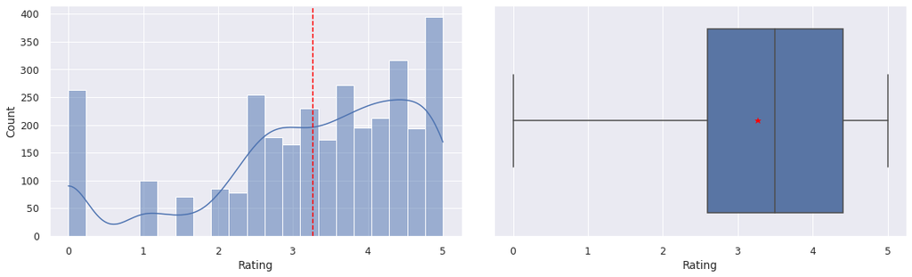

```python
plt.figure(figsize = (16, 5));
plt.subplot(121);
sns.histplot(data = df, x = 'Rating', kde = True);
plt.axvline(df['Rating'].mean(), color = 'red', linestyle = '--');
plt.subplot(122);
sns.boxplot(data = df, x = 'Rating', showmeans = True, meanprops =
                {'marker': '*', 'markerfacecolor': 'red', 'markeredgecolor': 'red', 'markersize': '9'});
plt.tight_layout(w_pad = 3);
```

#### Observations:

The rating distribution is also fairly discrete, but not as much as that of discount, as it takes rational numbers too. The average rating of ~ 3.3 is not very impressive.

**`Reviews`**

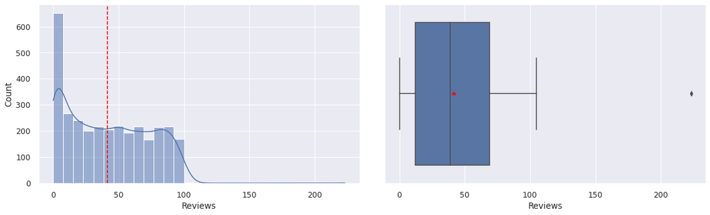

```python
plt.figure(figsize = (16, 5));
plt.subplot(121);
sns.histplot(data = df, x = 'Reviews', kde = True);
plt.axvline(df['Reviews'].mean(), color = 'red', linestyle = '--');
plt.subplot(122);
sns.boxplot(data = df, x = 'Reviews', showmeans = True, meanprops =
                {'marker': '*', 'markerfacecolor': 'red', 'markeredgecolor': 'red', 'markersize': '9'});
plt.tight_layout(w_pad = 3);
```

#### Observations:

The distribution of reviews has a peak around zero, since many shoes get no or very few reviews. It becomes fairly uniform until around 100, after which it experiences a sudden drop. Basically, there are only two shoes with reviews more than 100: one with 105 reviews and the other with 223 reviews.

**`CDF Plots of Numerical Variables`**

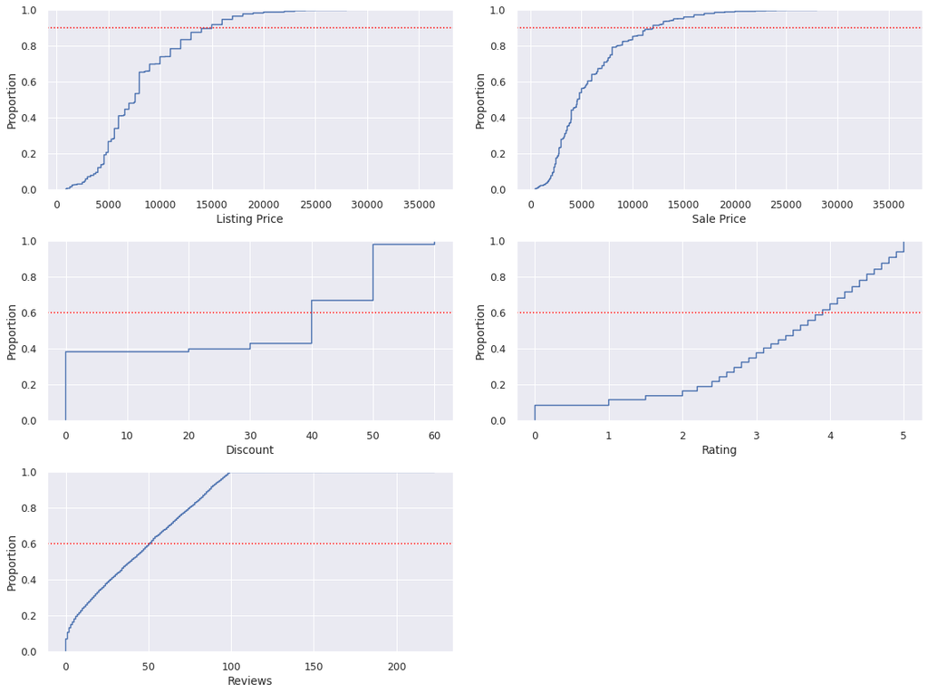

```python
# Listing the numerical features
num_cols = df.select_dtypes(include = np.number).columns.tolist()
# Demonstrating the CDF plots of all numerical variables
plt.figure(figsize = (16, 12));
for i, col in enumerate(num_cols):
    plt.subplot(3, 2, i+1);
    sns.ecdfplot(data = df, x = col);
    if(col == 'Listing Price' or col == 'Sale Price'):
        plt.axhline(0.9, color = 'red', linestyle = ':');
    else:
        plt.axhline(0.6, color = 'red', linestyle = ':');
plt.tight_layout(w_pad = 2);
```

### Bivariate Analysis

**`Heatmap of Correlation Coefficients`**

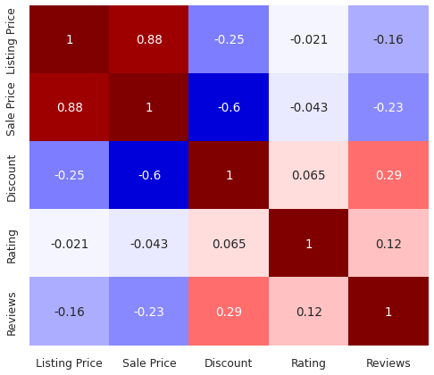

```python
plt.figure(figsize = (8, 7));
sns.heatmap(data = df.corr(), annot = True, cbar = False, cmap = 'seismic',
            vmin = -1, vmax = 1);
```

#### Observations:

- Unsurprisingly, listing and sales prices are heavily correlated, as listing price = discount * sale price.
- Vendors reduce the percentage of discount for more expensive items, hence the negative correlation between the two.
- More expensive items are sold less often and, thus have fewer reviews, which explains the negative correlation between the price and reviews.
- Products with higher discounts are more likely to be sold and, as a result, to have higher numbers of reviews, hence the positive correlation between the percentage of discount and the number of reviews.

**`Pairplots of Numerical Variables`**

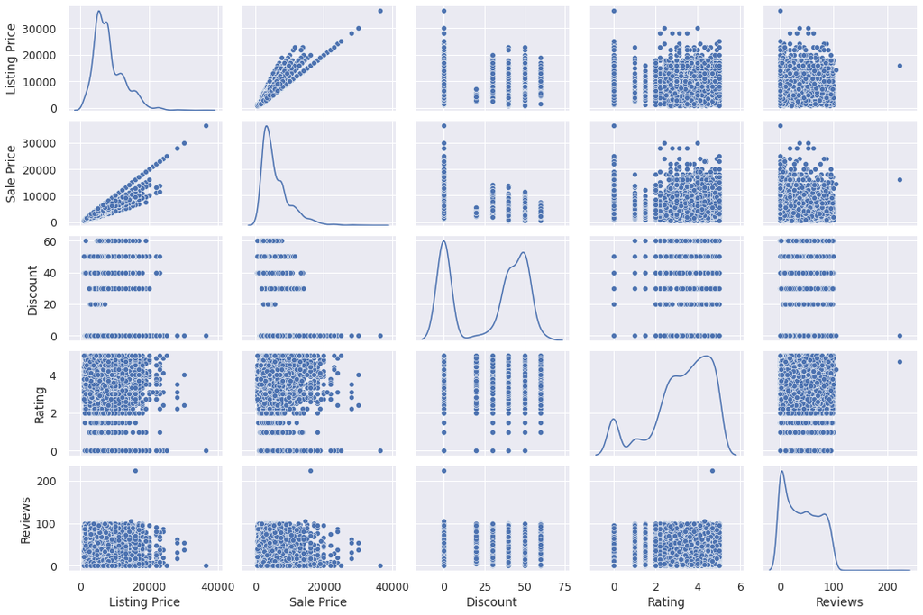

```python
sns.pairplot(data = df, diag_kind = 'kde', height = 2, aspect = 1.5, diag_kws = {'fill': False});
```

#### Observations:

- Several variables exhibit multimodal distributions (KDE plots), suggesting that on optimal clustering strategy may require us to put the products in several segments.
- The scatter plots show that only sale and listing price have a strong correlation.

## K-Means Clustering

### Preprocessing

Here, we make a subset of original dataframe, containing only numerical columns, then apply *standard scaling* to them.

```python
# Dropping the brand column
df_clust = df.drop(columns = 'Brand', axis = 1)

# Defining the scaler
scaler = StandardScaler()
# Producing the scaled dataframe
df_clust_scaled = pd.DataFrame(scaler.fit_transform(df_clust), columns = df_clust.columns.tolist())
df_clust_scaled.head()
```

|  | Listing Price | Sale Price | Discount | Rating | Reviews |
| --- | --- | --- | --- | --- | --- |
| 0 | 1.543 | 0.351 | 0.995 | 1.100 | -0.017 |
| 1 | -0.153 | -0.532 | 0.995 | 0.024 | -0.559 |
| 2 | -1.666 | -1.295 | 0.551 | -0.478 | -0.144 |
| 3 | -0.291 | -0.603 | 0.995 | 0.598 | -0.208 |
| 4 | -0.062 | -0.484 | 0.995 | 0.167 | 0.971 |

### Generating K-Elbow Plot

Here, we vary the number of clusters (k) from 1 to 10 and generate the mean distortions plot w.r.t. k.

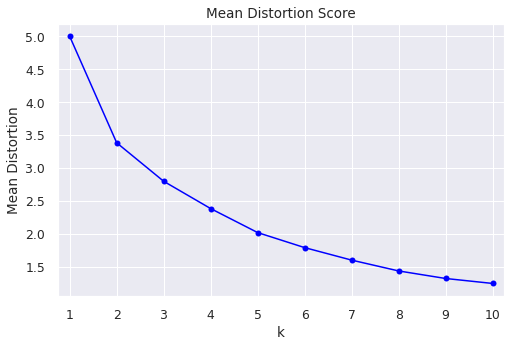

```python
# Range of k values
k_range = np.arange(1, 11)
mean_distorions = np.zeros(len(k_range))
# Looping over all k values
for k in k_range:
    kmeans_model = KMeans(n_clusters = k, random_state = 1)
    segments_pred = kmeans_model.fit_predict(df_clust_scaled)
    mean_distorions[k-1] = sum(np.min(np.square(cdist(df_clust_scaled, kmeans_model.cluster_centers_, 'Euclidean')),
                                      axis = 1))/df_clust_scaled.shape[0]
# Plotting mean distrotion for all values of k
plt.figure(figsize = (8, 5));
plt.plot(k_range, mean_distorions, color = 'blue', marker = 'o');
plt.xticks(ticks = k_range);
plt.xlim(k_range[0]-0.25, k_range[-1]+0.25);
plt.xlabel('k');
plt.ylabel('Mean Distortion');
plt.title('Mean Distortion Score');
```

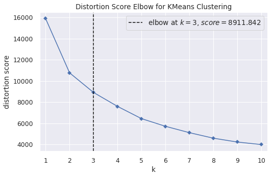

```python
# Using Python's method
plt.figure(figsize = (8, 5));
visualizer = KElbowVisualizer(estimator = KMeans(random_state = 1), k = k_range, timings = False)
visualizer.fit(df_clust_scaled)
plt.xticks(ticks = k_range);
plt.xlim(k_range[0]-0.25, k_range[-1]+0.25);
visualizer.show();
```

#### Observations:

- Note that both elbow plots represent the same thing, except the scores of the first plot are averaged over the entire clusters.
- Above elbow plots don't reveal a clear-cut optimal k. The plot generated by Yellowbrick's method declares k = 3 as the optimal value, but k = 4 or 5 also don't look too different. Therefore, we will determine the optimal value of k among these candidates via silhouette score.

### Comparing Silhouette Scores

Since the results of the K-Elbow plot weren't very definitive, we calculate the silhouette score for each k value, as well.

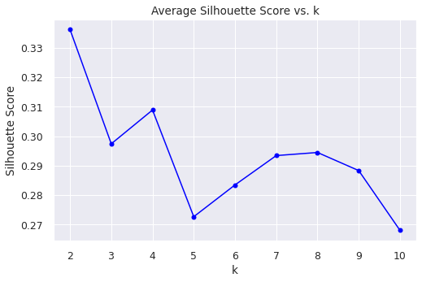

```python
# Calculating the mean silhouette score for all values of k

# Array of silhouette scores for all values of k
sil_scores = np.zeros(len(k_range)-1);

# Looping over all k values
for k in k_range[1:]:
    kmeans_model = KMeans(n_clusters = k, random_state = 1)
    segments_pred = kmeans_model.fit_predict(df_clust_scaled)
    sil_scores[k-2] = silhouette_score(df_clust_scaled, kmeans_model.labels_)

# Plotting the variation of silhouetter score with k
plt.figure(figsize = (8, 5));
plt.plot(k_range[1:], sil_scores, color = 'blue', marker = 'o');
plt.xlabel('k');
plt.ylabel('Silhouette Score');
plt.title('Average Silhouette Score vs. k');
```

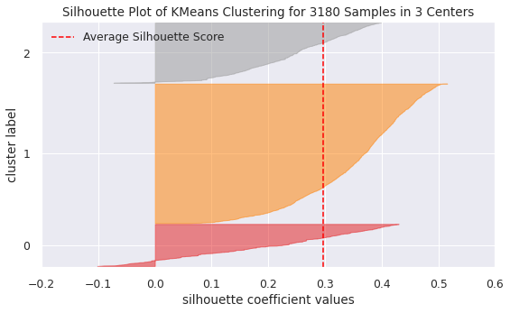

```python
# Generating the silhouette plot for k = 3
plt.figure(figsize = (9, 5));
visualizer = SilhouetteVisualizer(estimator = KMeans(n_clusters = 3, random_state = 1));
visualizer.fit(df_clust_scaled);
visualizer.show();
```

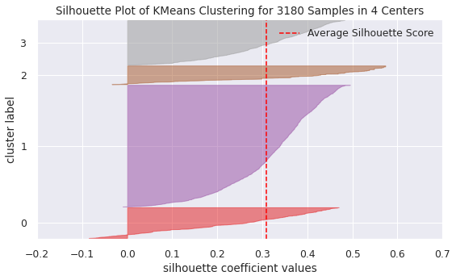

```python
# Generating the silhouette plot for k = 4
plt.figure(figsize = (9, 5));
visualizer = SilhouetteVisualizer(estimator = KMeans(n_clusters = 4, random_state = 1));
visualizer.fit(df_clust_scaled);
visualizer.show();
```

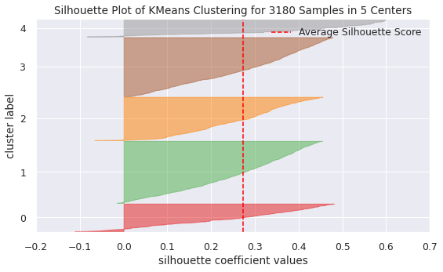

```python
# Generating the silhouette plot for k = 5
plt.figure(figsize = (9, 5));
visualizer = SilhouetteVisualizer(estimator = KMeans(n_clusters = 5, random_state = 1));
visualizer.fit(df_clust_scaled);
visualizer.show();
```

#### Observations:

Among the three candidates, k = 4 renders the highest average silhouette score, which is an indication that how well separated the clusters are.

### Making Predictions with the Best k Value

Building the model using the value of k that leads to the best compromise between compression and accuracy.

```python
# Building the final model
final_kmeans_model = KMeans(n_clusters = 4, random_state = 1);
# Deciding the cluster of each data point using the final model
segments_pred = final_kmeans_model.fit_predict(df_clust_scaled)

# Adding the determined clusters to the original and the scaled datasets
df_kmeans = df.copy()
df_kmeans_scaled = df_clust_scaled.copy()
df_kmeans['Cluster'] = segments_pred
df_kmeans_scaled['Cluster'] = segments_pred
```

```python
# Checking a few predictions on the original dataset
df_kmeans.sample(10)
```

|  | Listing Price | Sale Price | Discount | Brand | Rating | Reviews | Cluster |
| --- | --- | --- | --- | --- | --- | --- | --- |
| 992 | 7599 | 3799 | 50 | Adidas ORIGINALS | 4.000 | 7 | 1 |
| 1847 | 7999 | 3999 | 50 | Adidas CORE/NEO | 4.400 | 56 | 1 |
| 460 | 6599 | 3959 | 40 | Adidas CORE/NEO | 2.400 | 22 | 1 |
| 2013 | 4599 | 4599 | 0 | Adidas SPORT | 3.400 | 28 | 3 |
| 2041 | 7999 | 3999 | 50 | Adidas ORIGINALS | 3.400 | 46 | 1 |
| 1019 | 1299 | 1299 | 0 | Adidas CORE/NEO | 4.600 | 17 | 3 |
| 1203 | 5999 | 2999 | 50 | Adidas CORE/NEO | 2.500 | 46 | 1 |
| 1927 | 7999 | 3999 | 50 | Adidas CORE/NEO | 1.000 | 45 | 1 |
| 3175 | 6495 | 6495 | 0 | Nike | 0.000 | 0 | 2 |
| 1163 | 4999 | 2999 | 40 | Adidas CORE/NEO | 1.500 | 43 | 1 |

## Cluster Profiling

### Demonstrating the Centroid of Each Cluster

Here, we demonstrate the center of each cluster, while highlighting in what cluster the maximum value of each feature occurs.

```python
# Calculating the centroid of each cluster
clust_centroids = df_kmeans.groupby('Cluster').mean()
# Adding the counts of each cluster to the dataframe
clust_centroids['Count'] = df_kmeans.Cluster.value_counts()[df_kmeans.Cluster.value_counts().index.sort_values()]
clust_centroids.style.highlight_max(color = 'lightgreen', axis = 0)
```

| Cluster | Listing Price | Sale Price | Discount | Rating | Reviews | Count |
| --- | --- | --- | --- | --- | --- | --- |
| 0 | 15535.947020 | 13400.571744 | 8.741722 | 3.933775 | 31.419426 | 453 |
| 1 | 6815.954824 | 3695.715003 | 45.448968 | 3.379643 | 50.064138 | 1793 |
| 2 | 9940.556364 | 8698.054545 | 6.254545 | 0.192364 | 9.560000 | 275 |
| 3 | 6525.737481 | 6190.259484 | 1.001517 | 3.783460 | 38.599393 | 659 |

### Feature Distribution for the Scaled Data

Here, we generate the boxplot distribution of each numerical feature w.r.t. the clusters the data points are falling in, for the scaled data.

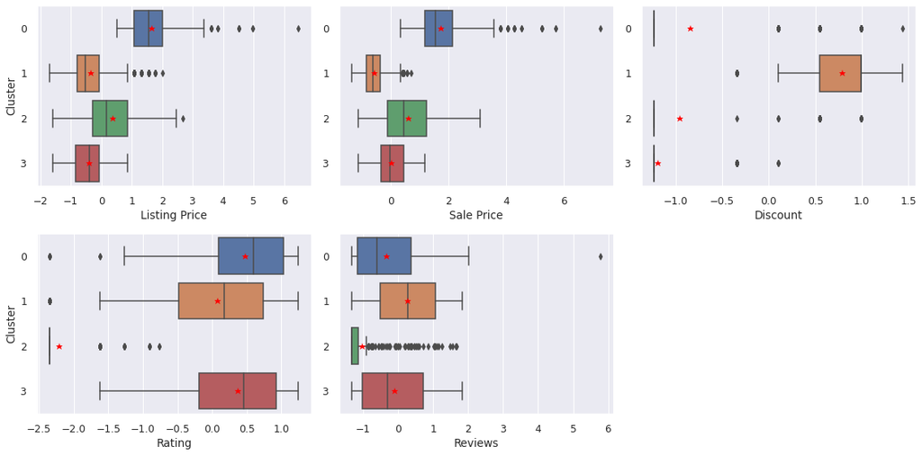

```python
# Listing the numerical features
num_cols = df_kmeans_scaled.select_dtypes(include = np.number).columns.tolist()
num_cols.remove('Cluster')
# Producing the boxplots w.r.t. clusters for each numerical variable
plt.figure(figsize = (16, 8));
for i, col in enumerate(num_cols):
    plt.subplot(2, 3, i+1);
    sns.boxplot(data = df_kmeans_scaled, x = col, y = 'Cluster', orient = 'h', showmeans = True, meanprops =
                {'marker': '*', 'markerfacecolor': 'red', 'markeredgecolor': 'red', 'markersize': '9'});
    if(i%3 != 0):
        plt.ylabel('');
plt.tight_layout();
```

### Feature Distribution for the Original Data

Here, we generate the boxplot distribution of each numerical feature w.r.t. the clusters the data points are falling in, for the original data.

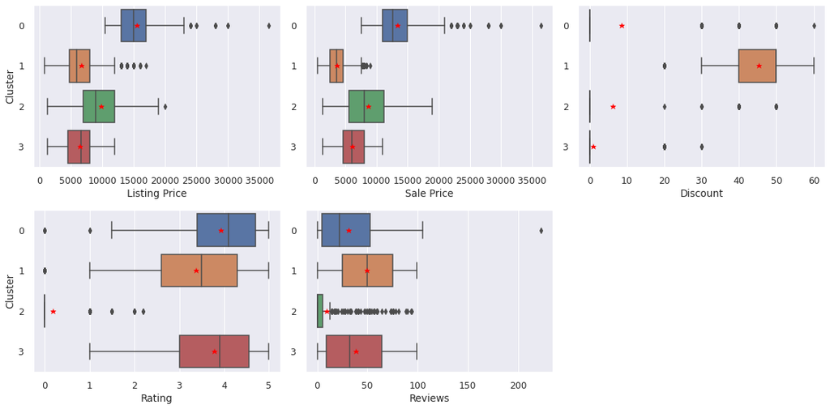

```python
# Listing the numerical features
num_cols = df_kmeans.select_dtypes(include = np.number).columns.tolist()
num_cols.remove('Cluster')
# Producing the boxplots w.r.t. clusters for each numerical variable
plt.figure(figsize = (16, 8));
for i, col in enumerate(num_cols):
    plt.subplot(2, 3, i+1);
    sns.boxplot(data = df_kmeans, x = col, y = 'Cluster', orient = 'h', showmeans = True, meanprops =
                {'marker': '*', 'markerfacecolor': 'red', 'markeredgecolor': 'red', 'markersize': '9'});
    if(i%3 != 0):
        plt.ylabel('');
plt.tight_layout();
```

#### Observations:

- Cluster 0 consists of more expensive and luxurious products, which also have higher ratings.
- Cluster 1 is made up of the most affordable shoes, which are sold more oftern and, as a result, have higher number of reviews.
- Unsurprisingly, cluster 1 which is supposed to attract lower-income customers gets the highest percentage of discount.
- The listing prices of cluster 1 and 3 are very close, but since the former gets more discounts, its sale price is noticeably lower.
- Cluster 2 has the lowest count, as most likely isn't produced and sold very often, usually has very few reviews and a much lower rating than the other clusters.

### Distribution of Brands in Different Clusters

```python
# Making a crosstab of brands and clusters
ctab = pd.crosstab(df_kmeans['Cluster'], df_kmeans['Brand'])
ctab.style.highlight_max(color = 'lightgreen', axis = 0)
```

| Brand Cluster | Adidas CORE/NEO | Adidas ORIGINALS | Adidas SPORT | Nike |
| --- | --- | --- | --- | --- |
| 0 | 0 | 133 | 128 | 192 |
| 1 | 866 | 569 | 358 | 0 |
| 2 | 15 | 47 | 20 | 193 |
| 3 | 230 | 159 | 100 | 170 |

#### Observations:

- More than 1/3 of Nike products are of premium class.
- But not all Nike are of high quality. About 1/3 of them also fall in cluster 2, which has the lowest customer satisfaction and is purchased less often.
- The majority of all three brands of Adidas fall in cluster 1, indicating they are designed to be more affordable, and that Adidas provides higher discounts for its products.

## Hierarchical Clustering

### Impact of Distance Metric and Linkage Method

Here, we determine which combination of distance (affinity) metric and linkage method result in the highest cophenetic correlation.

```python
# Listing the distance metrics and linkage methods
dist_metrics = ['cityblock', 'euclidean', 'chebyshev', 'mahalanobis']
link_methods = ['single', 'complete', 'average']

# cophenetic correlation matrix of all combinations
c = np.zeros((len(dist_metrics), len(link_methods)))

# Looping over all metrics and methods
for i, dist_metric in enumerate(dist_metrics):
    for j, link_method in enumerate(link_methods):
        # Performing agglemorative clustering for the given distance metric and linkage method
        Z = linkage(df_clust_scaled, metric = dist_metric, method = link_method)
        # Computing the cophenetic correlation
        c[i][j], coph_dists = cophenet(Z, pdist(df_clust_scaled))

print('Maximum cophenetic correlation attained is {}.'.format(round(np.max(c), 3)))
print('Linkage Method leading to maximum cophenetic correlation:',
      dist_metrics[np.unravel_index(np.argmax(c), c.shape)[0]])
print('Linkage Method leading to maximum cophenetic correlation:',
      link_methods[np.unravel_index(np.argmax(c), c.shape)[1]])
```

```
Maximum cophenetic correlation attained is 0.779.
Linkage Method leading to maximum cophenetic correlation: cityblock
Linkage Method leading to maximum cophenetic correlation: average
```

#### Observations:

- Among provided distance metrics and linkage methods the combination of *city block* and *average* result in the highest cophenetic correlation. However, we also need to see how the combination of euclidean distance with centroid and Ward's methods work before making the final decision.
- Note that centroid and Ward's linkage methods can't be combined by any other metric besides Euclidean, and that's why we didn't include them in the loop.

```python
# List of linkage methods only compatible with Euclidean
link_methods = ['centroid', 'ward']

for link_method in link_methods:
    # Performing agglemorative clustering for the Euclidean distance metric and the given linkage method
    Z = linkage(df_clust_scaled, metric = 'euclidean', method = link_method)
    # Computing the cophenetic correlation
    cc, coph_dists = cophenet(Z, pdist(df_clust_scaled))
    print('For Euclidean distance metric and {} linkage method, the cophenetic correlation is {}.'
          .format(link_method, round(cc, 3)))
    del Z, coph_dists
```

```
For Euclidean distance metric and centroid linkage method, the cophenetic correlation is 0.746.
For Euclidean distance metric and ward linkage method, the cophenetic correlation is 0.52.
```

#### Observations:

None of the Ward's or centroid method (combined with Euclidean distance) can improve the result of city block distance metric and average linkage method.

### Selecting the Optimal Number of Clusters

Here, we explore the dendrogram for the pair of affinity and linkage leading to the highest cophenetic correlation, in order to select the optimal number of threshold or the cutting threshold for distances between the clusters.

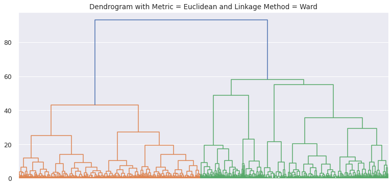

```python
# Dendogram of with the default hyperparameters of agglomerative clustering
Z = linkage(df_clust_scaled, metric = 'euclidean', method = 'ward')
plt.figure(figsize = (13, 6));
dendrogram(Z);
plt.title('Dendrogram with Metric = Euclidean and Linkage Method = Ward');
plt.xticks([]);
```

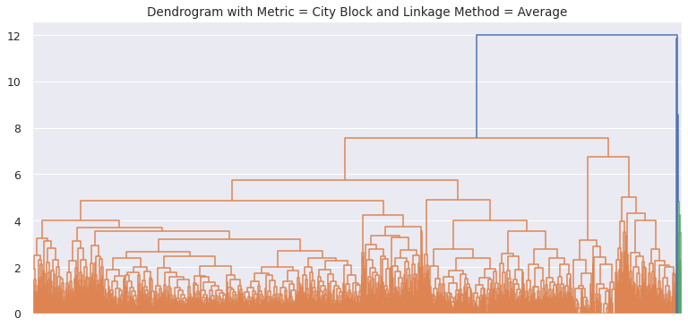

```python
# Dendogram of with the hyperparameters resulting in the highest cc
Z = linkage(df_clust_scaled, metric = 'cityblock', method = 'average')
plt.figure(figsize = (13, 6));
dendrogram(Z);
plt.title('Dendrogram with Metric = City Block and Linkage Method = Average');
plt.xticks([]);
```

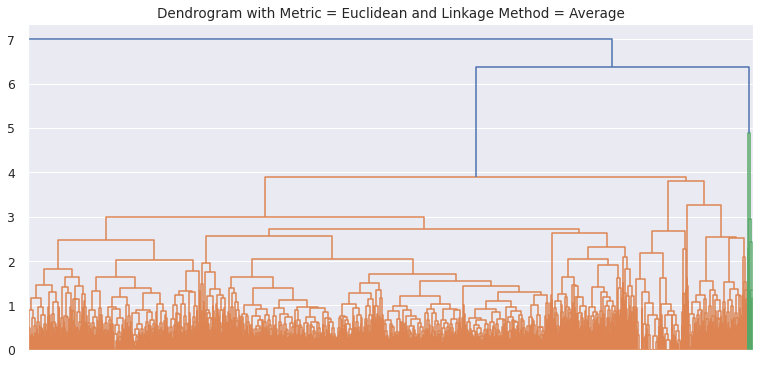

```python
# Dendogram of with the hyperparameters resulting in the second highest cc
Z = linkage(df_clust_scaled, metric = 'euclidean', method = 'average')
plt.figure(figsize = (13, 6));
dendrogram(Z);
plt.title('Dendrogram with Metric = Euclidean and Linkage Method = Average');
plt.xticks([]);
```

#### Observations:

- However the default hyperparameters of the agglomerative clustering method resulted in a fairly low cophenetic correlation, but it's been able to separate data points into far more distinct clusters than the pairs of distance metrics and linkage methods leading to the top two highest cophenetic correlations. Therefore, we'll choose to proceed with the default hyperparameters of the agglomerative clustering method while building the final method.
- Seemingly, the Ward's method is much more successful than other linkage methods in separating data points into distinguishable clusters.
- The optimal number of clusters appears to be 3.

### Building the Final Model

```python
# Building the final hierarchical clustering model using
# distance metric = Euclidean & linkage method = ward's
final_hc_model = AgglomerativeClustering(n_clusters = 3)
# Determining the cluster of each data point using the built model
clusters_pred = final_hc_model.fit_predict(df_clust_scaled)

# Adding the determined clusters to the original and the scaled datasets
df_hc = df.copy()
df_hc_scaled = df_clust_scaled.copy()
df_hc['Cluster'] = clusters_pred
df_hc_scaled['Cluster'] = clusters_pred
```

```python
# Checking a few predictions on the original dataset
df_hc.sample(8)
```

|  | Listing Price | Sale Price | Discount | Brand | Rating | Reviews | Cluster |
| --- | --- | --- | --- | --- | --- | --- | --- |
| 2600 | 7999 | 7999 | 0 | Adidas SPORT | 2.700 | 50 | 0 |
| 1967 | 11999 | 7199 | 40 | Adidas SPORT | 3.400 | 43 | 2 |
| 700 | 4299 | 2149 | 50 | Adidas CORE/NEO | 3.200 | 82 | 1 |
| 1317 | 7999 | 7999 | 0 | Adidas ORIGINALS | 2.700 | 31 | 0 |
| 1694 | 6599 | 3959 | 40 | Adidas ORIGINALS | 1.500 | 72 | 1 |
| 676 | 4599 | 2299 | 50 | Adidas CORE/NEO | 2.800 | 58 | 1 |
| 3137 | 16995 | 10197 | 0 | Nike | 0.000 | 0 | 0 |
| 1047 | 2699 | 1889 | 30 | Adidas CORE/NEO | 2.000 | 26 | 1 |

### Demonstrating the Centroid of Each Cluster

Displaying the center of each cluster, while highlighting the maximum value of each feature

```python
# Calculating the center of each cluster
clust_centroids = df_hc.groupby('Cluster').mean()
# Adding the counts of each cluster to the dataframe
clust_centroids['Count'] = df_hc.Cluster.value_counts()[df_hc.Cluster.value_counts().index.sort_values()]
clust_centroids.style.highlight_max(color = 'lightgreen', axis = 0)
```

| Cluster | Listing Price | Sale Price | Discount | Rating | Reviews | Count |
| --- | --- | --- | --- | --- | --- | --- |
| 0 | 8173.860335 | 7687.770950 | 1.061453 | 3.018250 | 33.209497 | 1074 |
| 1 | 5992.478261 | 3243.803069 | 45.632992 | 3.318798 | 48.682864 | 1564 |
| 2 | 15022.035055 | 10771.675277 | 28.265683 | 3.608303 | 37.374539 | 542 |

### Feature Distribution for the Scaled Data

Displaying the boxplot distribution of each numerical feature w.r.t. the clusters for the scaled data

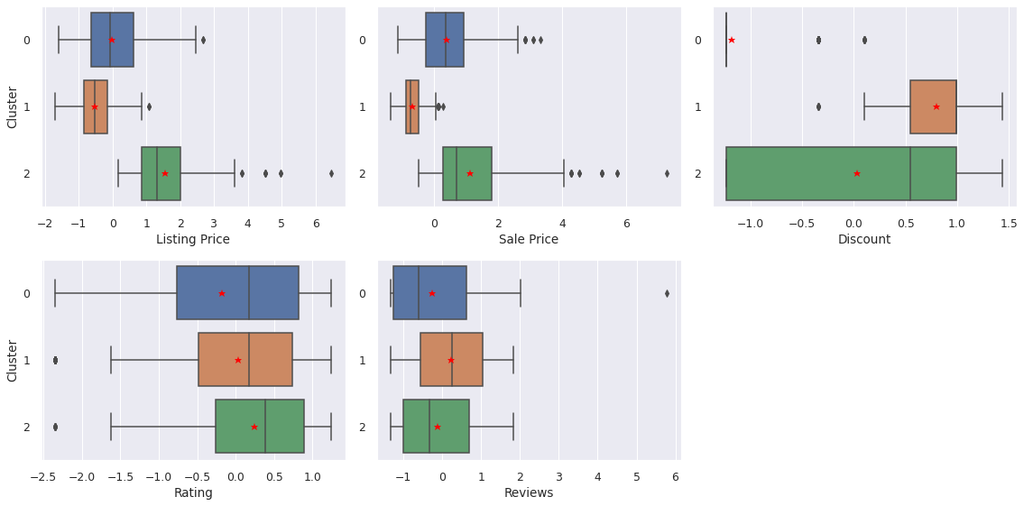

```python
# Listing the numerical features
num_cols = df_hc_scaled.select_dtypes(include = np.number).columns.tolist()
num_cols.remove('Cluster')
# Producing the boxplots w.r.t. clusters for each numerical variable
plt.figure(figsize = (16, 8));
for i, col in enumerate(num_cols):
    plt.subplot(2, 3, i+1);
    sns.boxplot(data = df_hc_scaled, x = col, y = 'Cluster', orient = 'h', showmeans = True, meanprops =
                {'marker': '*', 'markerfacecolor': 'red', 'markeredgecolor': 'red', 'markersize': '9'});
    if(i%3 != 0):
        plt.ylabel('');
plt.tight_layout();
```

### Feature Distribution for the Original Data

Displaying the boxplot distribution of each numerical feature w.r.t. the clusters for the original data

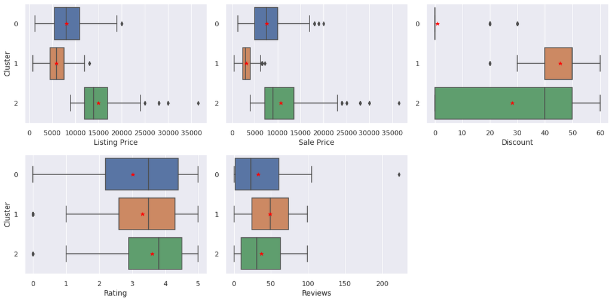

```python
# Listing the numerical features
num_cols = df_hc.select_dtypes(include = np.number).columns.tolist()
num_cols.remove('Cluster')
# Producing the boxplots w.r.t. clusters for each numerical variable
plt.figure(figsize = (16, 8));
for i, col in enumerate(num_cols):
    plt.subplot(2, 3, i+1);
    sns.boxplot(data = df_hc, x = col, y = 'Cluster', orient = 'h', showmeans = True, meanprops =
                {'marker': '*', 'markerfacecolor': 'red', 'markeredgecolor': 'red', 'markersize': '9'});
    if(i%3 != 0):
        plt.ylabel('');
plt.tight_layout();
```

### Distribution of Brands Across Clusters

```python
# Making a crosstab of brands and clusters
ctab = pd.crosstab(df_hc['Cluster'], df_hc['Brand'])
ctab.style.highlight_max(color = 'lightgreen', axis = 0)
```

| Brand Cluster | Adidas CORE/NEO | Adidas ORIGINALS | Adidas SPORT | Nike |
| --- | --- | --- | --- | --- |
| 0 | 258 | 251 | 140 | 425 |
| 1 | 851 | 428 | 285 | 0 |
| 2 | 2 | 229 | 181 | 130 |

#### Observations:

- The popularity of all Adidas brands fall in cluster 1, which corresponds to affordable products. This is consistent with the findings of k-means clustering.
- The majority of Nike shoes fall in cluster 0, which is medium in price. Interestingly, none of the Nike products are in the affordable cluster.